# Protein_aggregation_vs_subcellular_location

### Interpretation:

Nothing super interesting to see when FL regions are also included to the analysis.

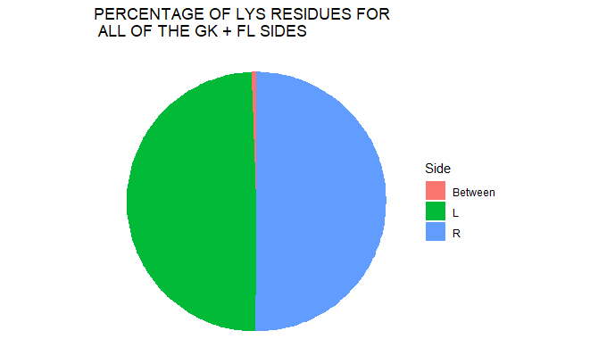

```r
pie_plot_percentage_of_specific_residue(GK_analysis_GK_and_FL_residues$lys_ct, "LYS", side_string)
```

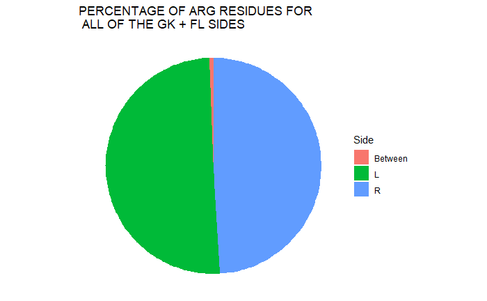

[figure not shown]

```r
pie_plot_percentage_of_specific_residue(GK_analysis_GK_and_FL_residues$arg_ct, "ARG", side_string)
```

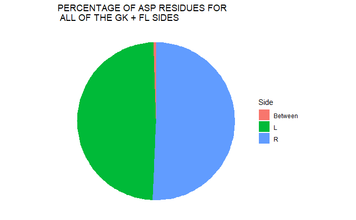

```r
pie_plot_percentage_of_specific_residue(GK_analysis_GK_and_FL_residues$asp_ct, "ASP", side_string)
```

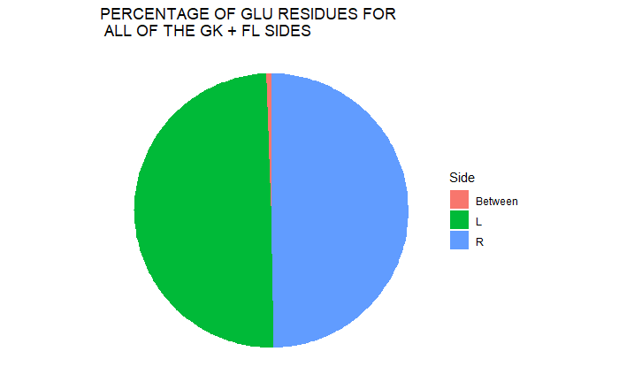

```r
pie_plot_percentage_of_specific_residue(GK_analysis_GK_and_FL_residues$glu_ct, "GLU", side_string)
```

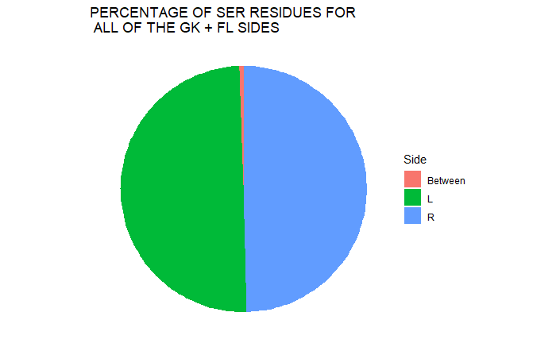

```r
pie_plot_percentage_of_specific_residue(GK_analysis_GK_and_FL_residues$ser_ct, "SER", side_string)
```

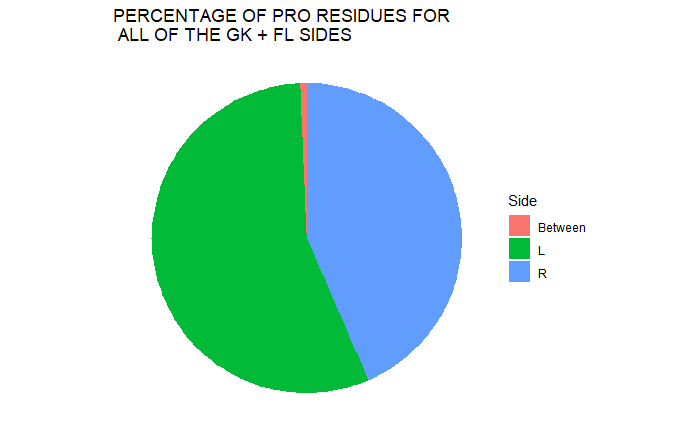

```r
pie_plot_percentage_of_specific_residue(GK_analysis_GK_and_FL_residues$pro_ct, "PRO", side_string)
```

## Interested Groups

### PERCENTAGE OF INTERESTED GROUPS FOR ALL THE GK SIDES

**analyse_gate_keeper_groups**: Obtain the side information for different groups of amino acids in the GK regions.

```r
GK_analysis_GK_groups = analyse_gate_keeper_groups(GK_analysis$cts_gk_groups_side)
side_string = "GK"
```

**pie_plot_percentage_of_specific_residue**: Plotting the side information for each amino acid group in GK regions.

### Interpretation:

There is a preference for left side of the GK for special case residues whereas there is also a big preference for right side of the GK regions for hydrophobic residues.

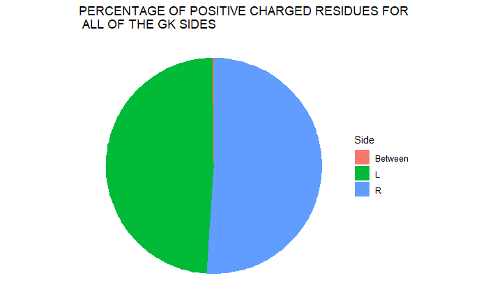

```r
pie_plot_percentage_of_specific_residue(GK_analysis_GK_groups$positive, "POSITIVE CHARGED", side_string)
```

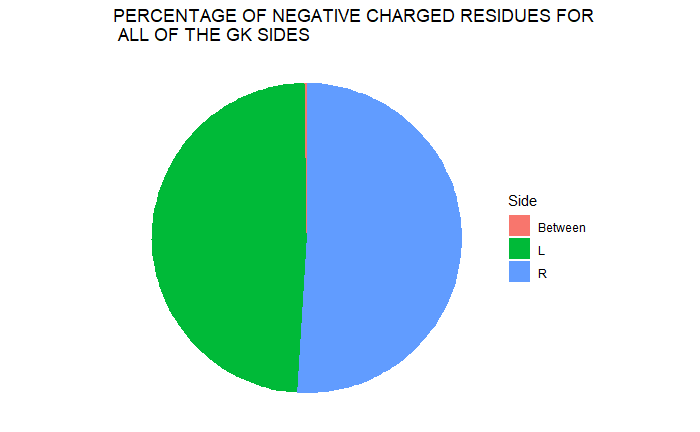

```r
pie_plot_percentage_of_specific_residue(GK_analysis_GK_groups$negative, "NEGATIVE CHARGED", side_string)
```

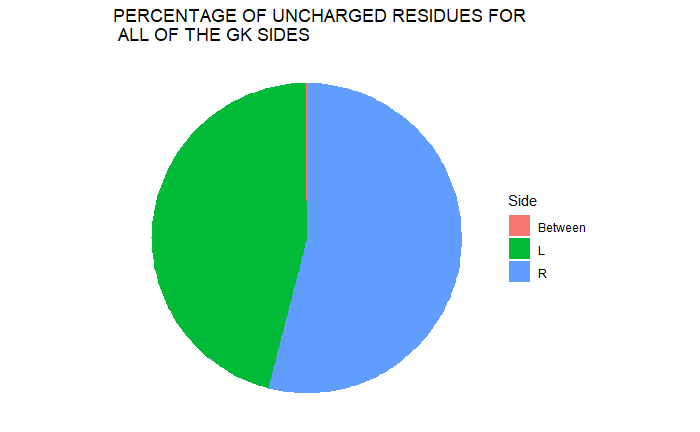

```r
pie_plot_percentage_of_specific_residue(GK_analysis_GK_groups$uncharged, "UNCHARGED", side_string)
```

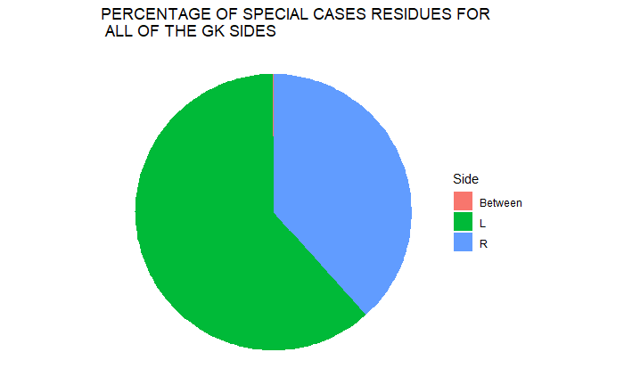

```r
pie_plot_percentage_of_specific_residue(GK_analysis_GK_groups$special, "SPECIAL CASES", side_string)
```

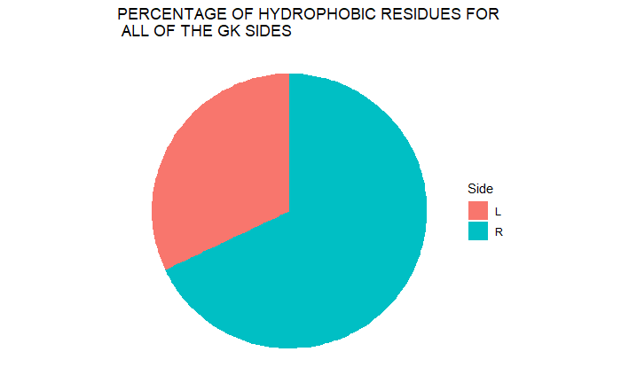

```r
pie_plot_percentage_of_specific_residue(GK_analysis_GK_groups$hydrophobic, "HYDROPHOBIC", side_string)
```

### PERCENTAGE OF INTERESTED RESIDUES FOR ALL OF THE GK + FL SIDES

**analyse_gate_keeper_groups**: Obtain the side information for different groups of amino acids in the GK + flanking regions.

```r
GK_analysis_GK_and_FL_groups = analyse_gate_keeper_groups(GK_analysis$cts_gk_fl_groups_side)
side_string = "GK + FL"
```

**pie_plot_percentage_of_specific_residue**: Plotting the side information for each amino acid group in GK + FL regions.

### Interpretation:

When GK + FL regions are considered, side distribution for all groups become nearly equal for left and right sides of the GK.

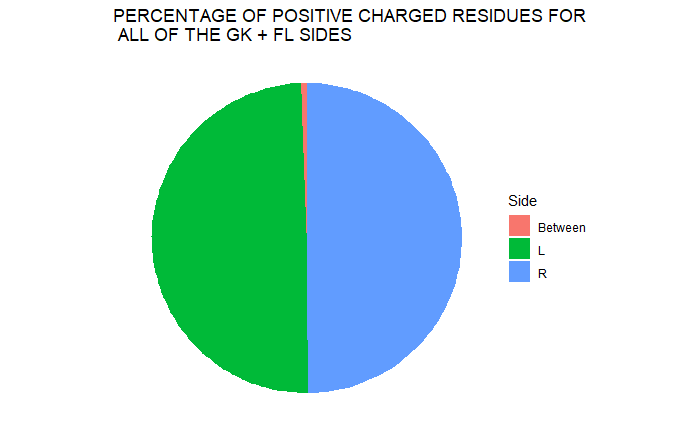

```r
pie_plot_percentage_of_specific_residue(GK_analysis_GK_and_FL_groups$positive, "POSITIVE CHARGED", side_string)
```

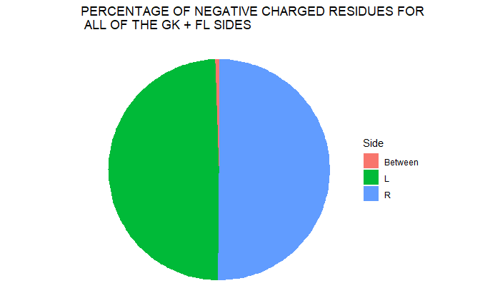

```r
pie_plot_percentage_of_specific_residue(GK_analysis_GK_and_FL_groups$negative, "NEGATIVE CHARGED", side_string)
```

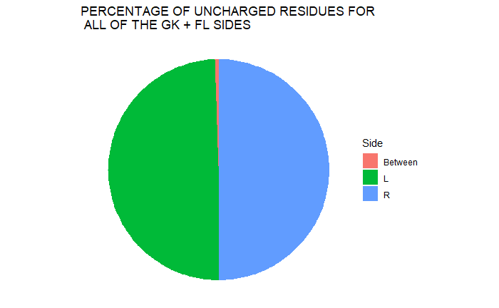

```r
pie_plot_percentage_of_specific_residue(GK_analysis_GK_and_FL_groups$uncharged, "UNCHARGED", side_string)
```

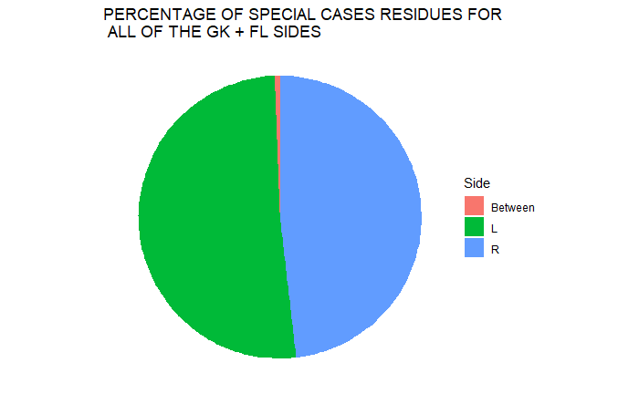

```r
pie_plot_percentage_of_specific_residue(GK_analysis_GK_and_FL_groups$special, "SPECIAL CASES", side_string)
```

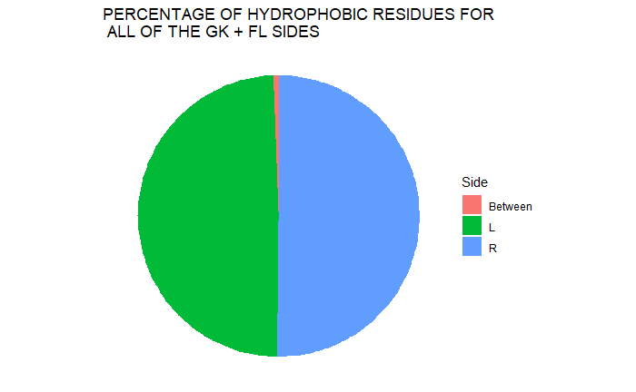

```r
pie_plot_percentage_of_specific_residue(GK_analysis_GK_and_FL_groups$hydrophobic, "HYDROPHOBIC", side_string)
```

## Now for the subcellular locations

**Previous analyses** are done for all of the proteins, but now we will be working on all the proteins that belong to a specific subcellular location.

### Functional Documentation:

**get_counts_for_subcellular_location**: To obtain the corresponding subset of proteins that are belonging to a specific subcellular location for determined counts.

**barplot_subcellular_location**: Function for plotting the residue percentage depending on the given category.

**barplot_ratio_for_each_subcellular_location**: Function plotting the ratio of the residue inside the subcellular location compared to the percentage of the residue inside all proteins of the dataset + also showing number of residues inside the subcellualr location

**analyse_interested_gate_keeper_regions**: Obtain the subset of proteins (only interest) for combination of regions.

**analyse_sides**: Obtain the percentage of single or groups of residues based on the given regions.

**pie_plot_sides**: Plotting the percentage of different sides for a given residue or a residue group.

### Interpretation:

**–Cell Membrane–**  
- Specific preference (more than 10%) for E,D and R in GK regions  
- 98% left preference for PRO in cell membrane protein GK regions  
- 68% right side preference for hydrophobic residues in GK regions of cell membrane proteins  
**–Mitochondrion–**  
- Increase in special residues in the GK regions  
- Specific preference (more than 10%) for E,D,K and R in GK regions  
- 96% left preference for PRO in cell membrane protein GK regions  
- 61% left preference for special cases in GK regions  
- 64% right preference for hydrophobic residues in GK regions  
**–Nucleus–**  
- Decrease in special residues in GK regions  
- Specific preference (more than 10%) for E,D,K and R in GK regions  
- 97% left preference for PRO in cell membrane protein GK regions  
- 62% left preference for special cases in GK regions  
- 66% right preference for hydrophobic residues in GK regions  
**–Endoplasmic Reticulum–**  
- Specific preference (more than 10%) for E,D,K and R in GK regions  
- Occurrence of between residues for GK regions  
- 62% left preference for special cases in GK regions  
- 67% right preference for hydrophobic residues in GK regions  
**–Golgi Apparatus–**  
- 26% preference for negative, positive, and uncharged residue groups  
- Specific preference (more than 10%) for E,D,K and R in GK regions with D being the highest (13.6%)  
- 98% left preference for PRO in cell membrane protein GK regions  
- 60% left preference for special cases in GK regions  
- 65% right preference for hydrophobic residues in GK regions  
**–Lysosome–**  
- 27.6% uncharged residue preference in the GK regions  
- Specific preference (more than 10%) for E,D,K and R in GK regions. S is close to 10% (9.2%)  
- 98% left preference for PRO in cell membrane protein GK regions  
- 62% left preference for special cases in GK regions  
- 70% right preference for hydrophobic residues in GK regions  
**–Cytoplasm–**  
- Specific preference (more than 10%) for E,D,K and R in GK regions  
- 97% left preference for PRO in cell membrane protein GK regions  
- 61% left preference for special cases in GK regions  
- 67% right preference for hydrophobic residues in GK regions  
**–Extracellular Space–**  
- 20% preference for special residues in GK regions  
- Specific preference (more than 10%) for E,D,K and R in GK regions with D being the highest (13.1%)  
- 96% left preference for PRO in cell membrane protein GK regions  
- 63% left preference for special cases in GK regions  
- 71% right preference for hydrophobic residues in GK regions

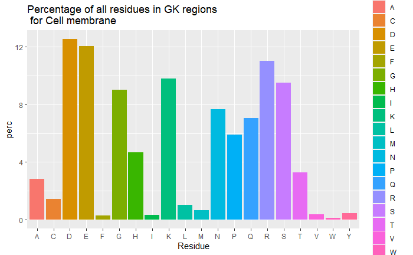

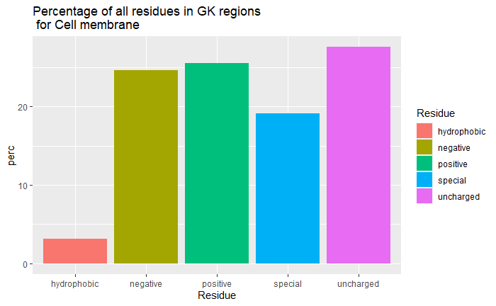

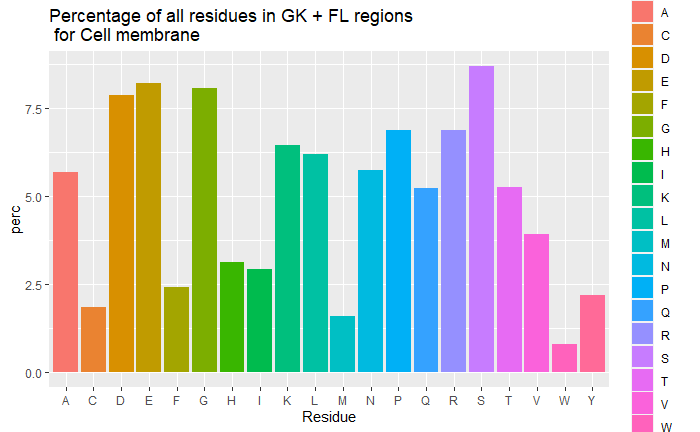

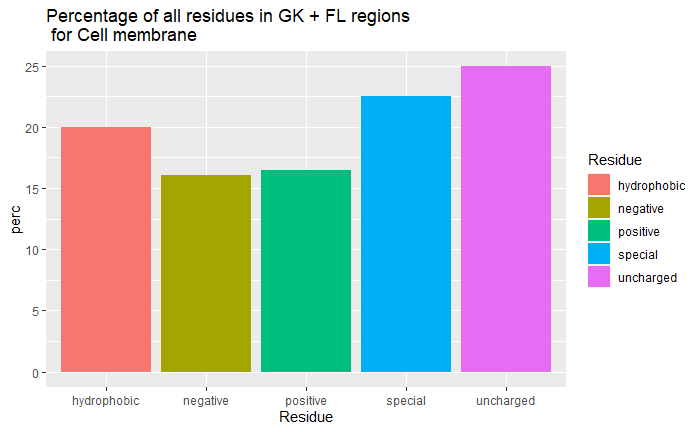

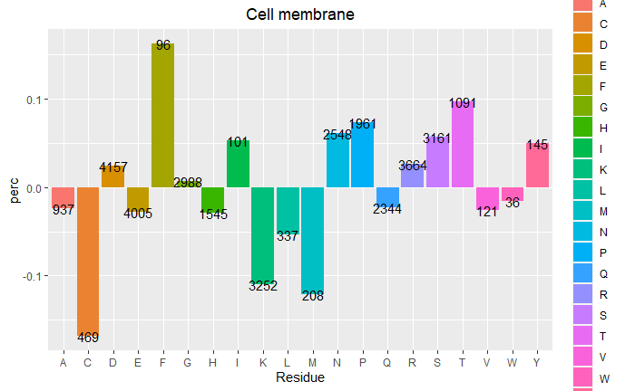

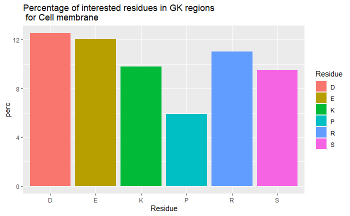

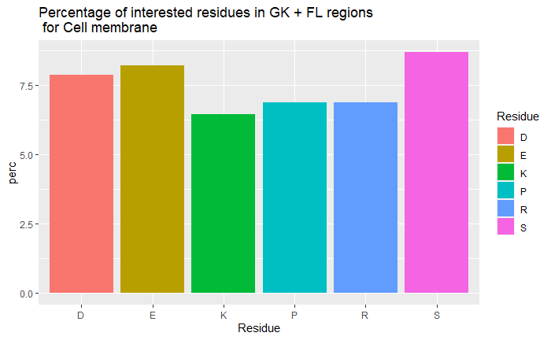

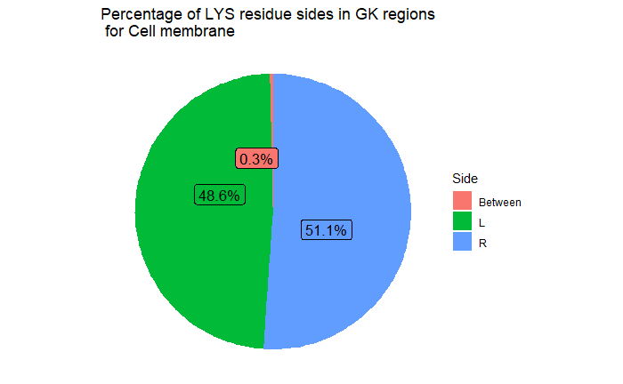

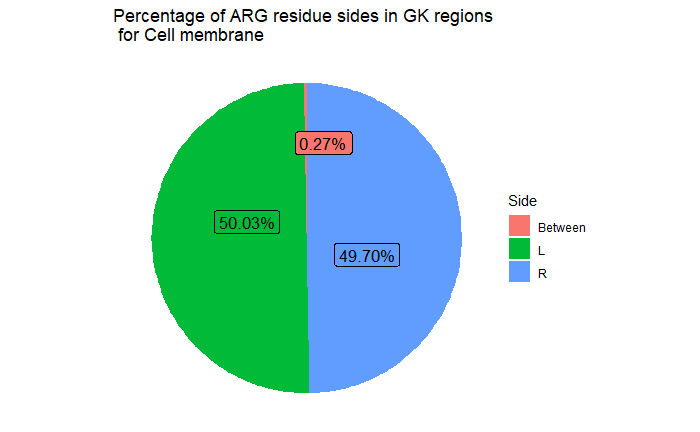

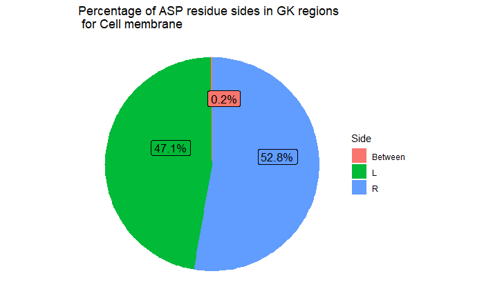

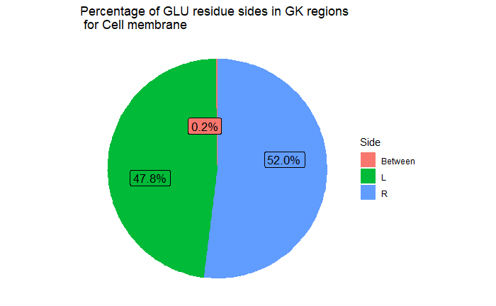

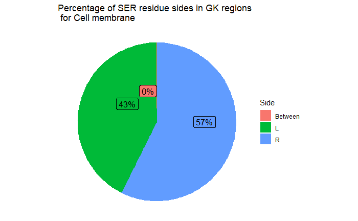

[220 more figures not shown]

```r
# Statistics for each subcellular location
for (i in 1:length(search_terms)) {
  counts = get_counts_for_subcellular_location(search_terms[i], GK_analysis) # Takes a while to run

  residue_category = "all"
  barplot_subcellular_location(counts$cts_gk, residue_category, "GK", search_terms[i])
  barplot_subcellular_location(counts$cts_gk_groups, residue_category, "GK", search_terms[i])
  barplot_subcellular_location(counts$cts_gk_fl, residue_category, "GK + FL", search_terms[i])
  barplot_subcellular_location(counts$cts_gk_fl_groups, residue_category, "GK + FL", search_terms[i])
  barplot_ratio_for_each_subcellular_location(counts$cts_gk, residue_category, "GK", search_terms[i])

  # PERCENTAGE OF INTERESTED PROTEINS IN SUBCELLULAR LOCATIONS

  counts_interest <- analyse_interested_gate_keeper_regions(counts)
  residue_category = "interested"
  barplot_subcellular_location(counts_interest$cts_interest_gk, residue_category, "GK", search_terms[i])
  barplot_subcellular_location(counts_interest$cts_interest_gk_fl, residue_category, "GK + FL", search_terms[i])

  # NOW THE SIDES PART
  counts_side_gk <- analyse_sides(counts$cts_gk_side)
  counts_side_gk_fl <- analyse_sides(counts$cts_gk_fl_side)
  counts_side_gk_groups <- analyse_sides(counts$cts_gk_groups_side)
  counts_side_gk_fl_groups <- analyse_sides(counts$cts_gk_fl_groups_side)

  region_string = "GK"
  pie_plot_sides(counts_side_gk$lys_ct, "LYS", region_string, search_terms[i])
  pie_plot_sides(counts_side_gk$arg_ct, "ARG", region_string, search_terms[i])
  pie_plot_sides(counts_side_gk$asp_ct, "ASP", region_string, search_terms[i])
  pie_plot_sides(counts_side_gk$glu_ct, "GLU", region_string, search_terms[i])
  pie_plot_sides(counts_side_gk$ser_ct, "SER", region_string, search_terms[i])
  pie_plot_sides(counts_side_gk$pro_ct, "PRO", region_string, search_terms[i])
  pie_plot_sides(counts_side_gk_groups$pos_ct, "positive", region_string, search_terms[i])
  pie_plot_sides(counts_side_gk_groups$neg_ct, "negative", region_string, search_terms[i])
  pie_plot_sides(counts_side_gk_groups$unc_ct, "uncharged", region_string, search_terms[i])
  pie_plot_sides(counts_side_gk_groups$spe_ct, "special cases", region_string, search_terms[i])
  pie_plot_sides(counts_side_gk_groups$hyd_ct, "hydrophobic", region_string, search_terms[i])

  region_string = "GK + FL"
  pie_plot_sides(counts_side_gk_fl$lys_ct, "LYS", region_string, search_terms[i])
  pie_plot_sides(counts_side_gk_fl$arg_ct, "ARG", region_string, search_terms[i])
  pie_plot_sides(counts_side_gk_fl$asp_ct, "ASP", region_string, search_terms[i])
  pie_plot_sides(counts_side_gk_fl$glu_ct, "GLU", region_string, search_terms[i])
  pie_plot_sides(counts_side_gk_fl$ser_ct, "SER", region_string, search_terms[i])
  pie_plot_sides(counts_side_gk_fl$pro_ct, "PRO", region_string, search_terms[i])
  pie_plot_sides(counts_side_gk_fl_groups$pos_ct, "positive", region_string, search_terms[i])
  pie_plot_sides(counts_side_gk_fl_groups$neg_ct, "negative", region_string, search_terms[i])
  pie_plot_sides(counts_side_gk_fl_groups$unc_ct, "uncharged", region_string, search_terms[i])
  pie_plot_sides(counts_side_gk_fl_groups$spe_ct, "special cases", region_string, search_terms[i])
  pie_plot_sides(counts_side_gk_fl_groups$hyd_ct, "hydrophobic", region_string, search_terms[i])
}
```

# STRUCTURAL ANALYSIS

```r
source("structural_analysis.R")
```

## Calculate the contact order and tango score for each domain and add it to the data frame

```r
load_full_domains()
```

## General plot + correlation test

###Functional Documentation:

**plot_domain_contact_order**: Scatterplot showing the relation between tango_scores and contact order for all proteins having a domain with tango score inside them. + results of correlation test of the two variables.

### Interpretation:

Contact order decreases, when tango scores increases.Correlation for this relation is 0.47 out of a score between 0 to 1. The relation is not that strong.

```
    Pearson's product-moment correlation

data:  domains$tango and domains$contact_order
t = -88.655, df = 27430, p-value < 2.2e-16
alternative hypothesis: true correlation is not equal to 0
95 percent confidence interval:
 -0.4810783 -0.4626814
sample estimates:
       cor
-0.4719312
```

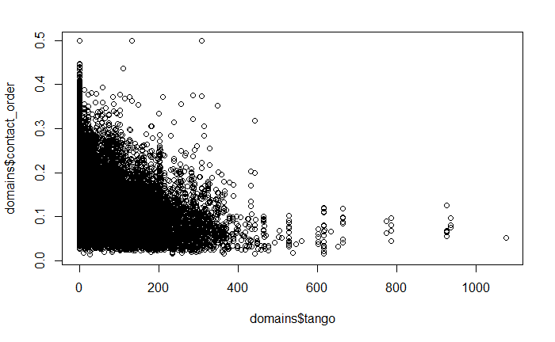

```r
plot_domains_contact_order()
```

##Plot for contact_order grouped

### Functional Documentation:

**get_grouped_domains**: Groups all the proteins for their contact order into 6 groups (<0.05, 0.05-0.10, 0.10-0.15, 0.15-0.20, 0.20-0.25 and >0.25). Leaves out all the NA values inside tango score and contact_order.

**plot_tango_contact_order_grouped**: Plot showing the relation between tango scores and contact order for the grouped data.

###Interpretation:

Showing visually a better representation of the relation between contact order and tango score.

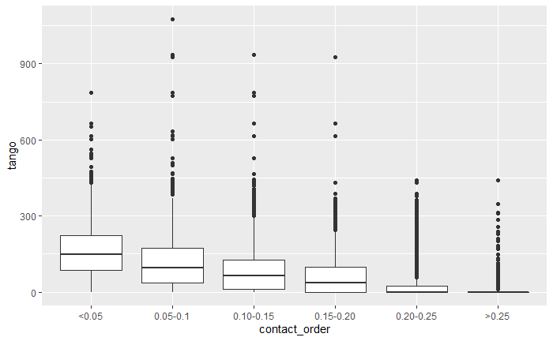

```r
grouped_domains <- get_grouped_domains()
plot_tango_contact_order_grouped(grouped_domains)
```

##Plot for contact_order grouped with NA sets to zero

### Functional Documentation:

**get_grouped_domains**: Groups all the proteins for their contact order into 6 groups (<0.05, 0.05-0.10, 0.10-0.15, 0.15-0.20, 0.20-0.25 and >0.25). Setting all the NA values inside contact_order to zero.

**plot_tango_contact_order_grouped**: Plot showing the relation between tango scores and contact order for the grouped data.

###Interpretation:

Showing visually a better representation of the relation between contact order and tango score.

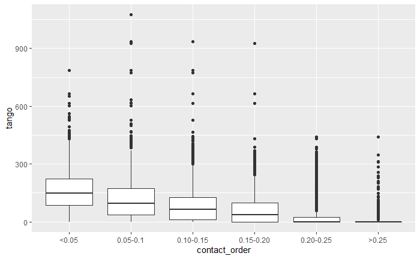

```r
grouped_domains_with_NA <- get_grouped_domains_NA_set_zero()
plot_tango_contact_order_grouped(grouped_domains_with_NA)
```

##2D density plots for each subcellular location - proteins with tango score of zero excluded

### Functional Documentation:

**plot_2D_contact_order_and_tango_in_subcellular_location_no_zero**: Two dimensional plot showing the relation between tango score and xontact order for each subcellular location. Showing where most of the proteins for that subcellular location are located. All proteins with a tango score of zero are not included.

### Interpretation:

**–Cell Membrane–**  
- contact order lies around 0.10, while there are two centers for tango scores. One around 80 and the other smaller center around 190.

**–Mitochondrion–**  
- Center at contact order equal to 0.05 and tango score equal to 100.

**–Nucleus–**  
- Two centers, one where contact order is higher at a score of 0.14 and tango score 20. The other where contact order is 0.10 and tango score is higher around 60.

**–Endoplasmic Reticulum–**  
- One center at contact order equal to 0.10 and tango score equal to 75.

**–Golgi Apparatus–**  
- Two centers, one where contact order is equal to 0.10 and tango score is equal to 70. The other where contact order is lower at 0.075 and tango score is higher around 175.

**–Lysosome–**  
- One plateau at contact_order around 0.10, and tango score lying between 35 and 120.

**–Extracellular space–**  
- Two centers, one where contact order is higher between 0.10 and 0.16, and tango score around 30. Other where contact order is around 0.10 and tango score is equal to 95.

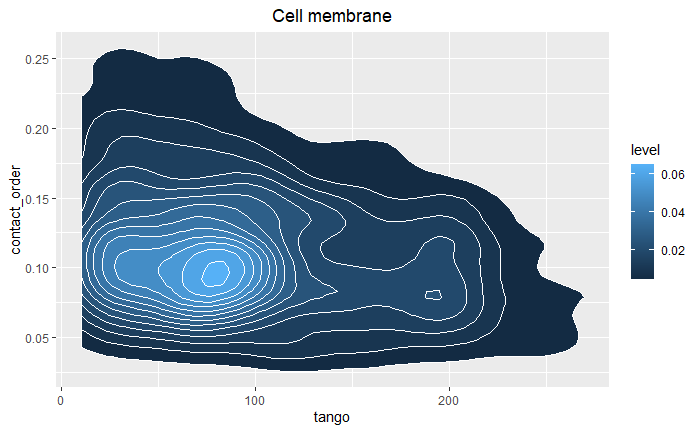

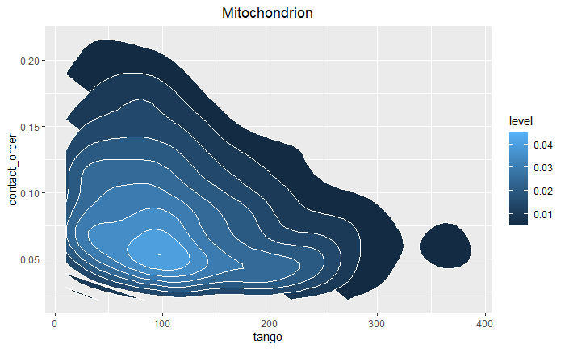

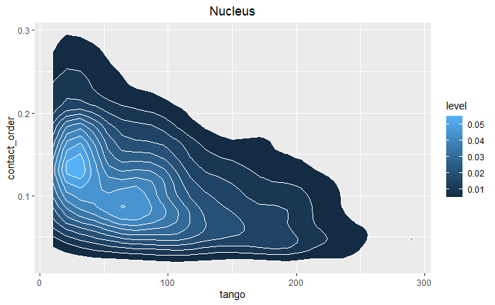

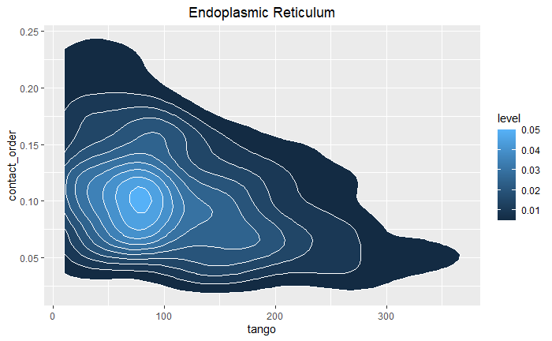

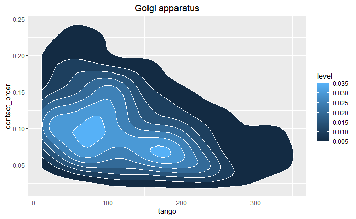

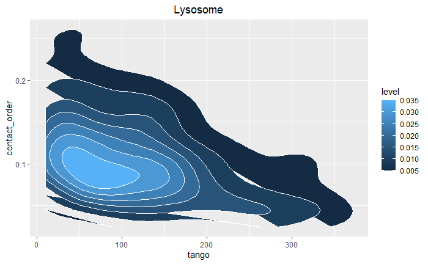

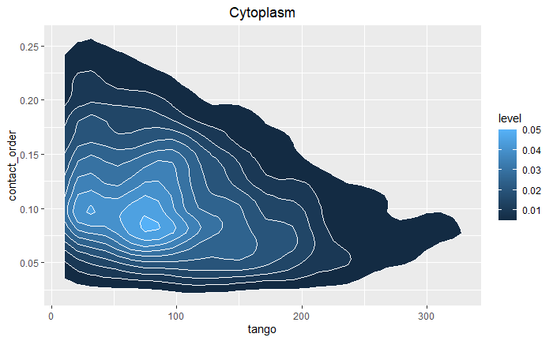

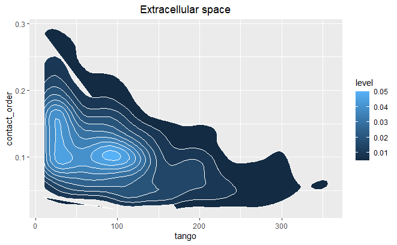

```r
plot_2D_contact_order_and_tango_in_subcellular_location_no_zero()
```

##2D density plots for each subcellular location - proteins with tango score of zero included

### Functional Documentation:

**plot_2D_contact_order_and_tango_in_subcellular_location**: 2 dimensional plot showing the relation between tango score and xontact order for each subcellular location. Showing where most of the proteins for that subcellular location are located. All proteins with a tango score of zero are included.

### Interpretation:

**–Cell Membrane–**  
- Two Ceners aroun contact order 0.10 and tango scores at 0 and 75. Third center forming where contact order is 0.09 and tango score is equal to 175.

**–Mitochondrion–**  
- Two centers, one around cotact order equal to 0.075 and tango score of 10. The othet at contact order of 0.05 and tango score equal to 100.

**–Nucleus–**  
- Plateau at tango score equal to zero and cotact order between 0.21 and 0.30.

**–Endoplasmic Reticulum–**  
- Two centers at contact order equalt to 0.10 and tango scores equal to 10 and 75.

**–Lysosome–**  
- One center at contact order equal to 0.10 and tango score equal to 10.

**–Cytoplasm–**  
- Two centers, one around contact order equal to 0.11 and tango score equal to 0. The other where contact order is equal to 75 0.09 and tango score is equal to 75.

**–Extracellular space–**  
One center where tango score is equal to zero and contact order is equal to 0.16. A plateau is also located where contact order is equal to 0.10 and tango scores are between 50 and 150.

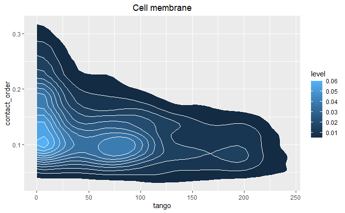

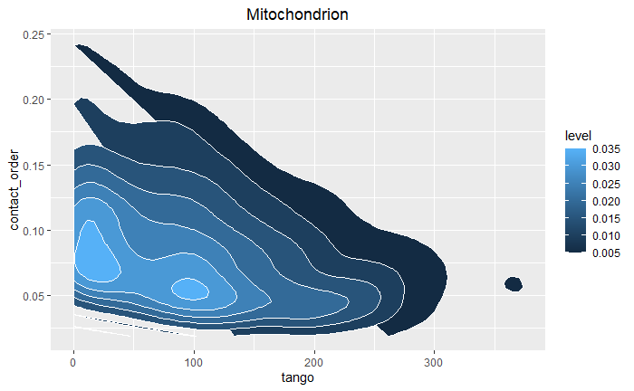

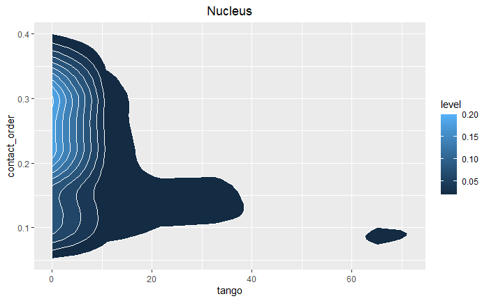

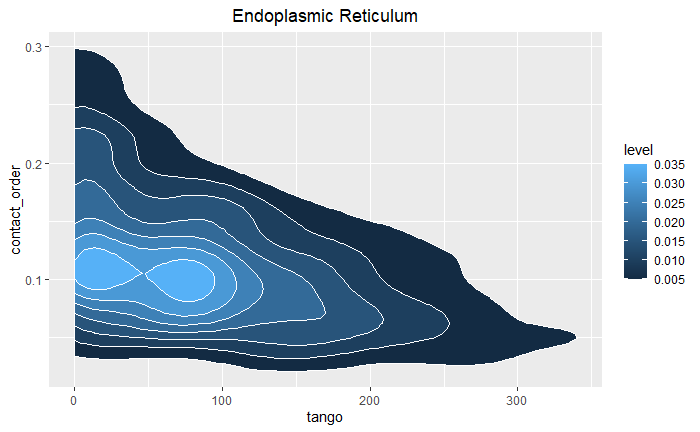

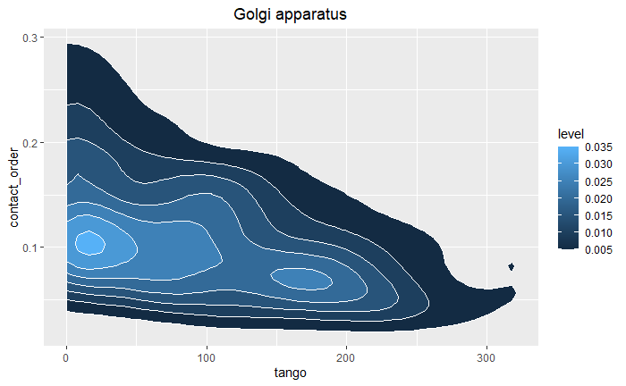

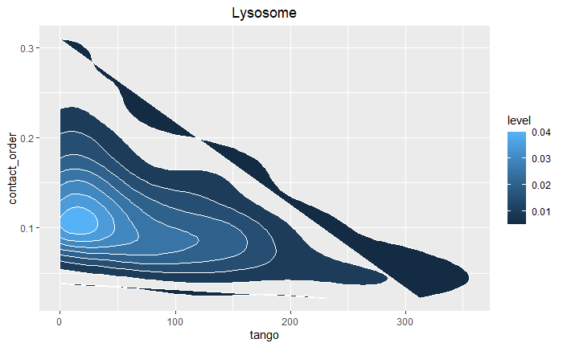

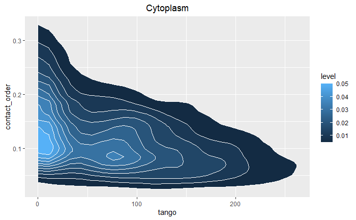

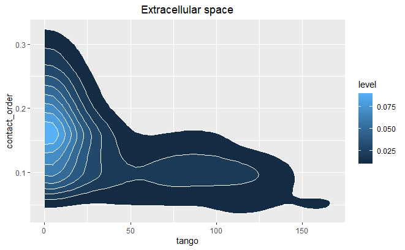

```r
plot_2D_contact_order_and_tango_in_subcellular_location()
```